# **Predicting the net hourly Electrical Energy Output of a Combined Cycle Power Plant**

[figure not shown]

**COMBINED CYCLE POWER PLANT**

# Introduction

The Combined Cycle Power Plant or combined cycle gas turbine, a gas turbine generator generates electricity and waste heat is used to make steam to generate additional electricity via a steam turbine. The gas turbine is one of the most efficient one for the conversion of gas fuels to mechanical power or electricity. The use of distillate liquid fuels, usually diesel, is also common as alternate fuels. More recently, as simple cycle efficiencies have improved and as natural gas prices have fallen, gas turbines have been more widely adopted for base load power generation, especially in combined cycle mode, where waste heat is recovered in waste heat boilers, and the steam used to produce additional electricity.

**The basic principle of the Combined Cycle is simple: burning gas in a gas turbine (GT) produces not only power - which can be converted to electric power by a coupled generator - but also fairly hot exhaust gases. Routing these gases through a water-cooled heat exchanger produces steam, which can be turned into electric power with a coupled steam turbine and generator.** *This type of power plant is being installed in increasing numbers round the world where there is access to substantial quantities of natural gas.*

# Mechanism

Combined cycle power plant as in name suggests, it combines existing gas and steam technologies into one unit, yielding significant improvements in thermal efficiency over conventional steam plant. *The term “combined cycle” refers to the combining of multiple thermodynamic cycles to generate power*. In a CCGT plant the thermal efficiency is extended to approximately 50-60 per cent, by piping the exhaust gas from the gas turbine into a heat recovery steam generator. However the heat recovered in this process is sufficient to drive a steam turbine with an electrical output of approximately 50 per cent of the gas turbine generator.

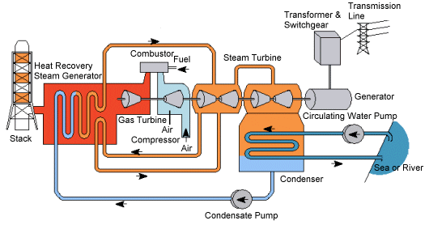

The gas turbine and steam turbine are coupled to a single generator. For startup, or ‘open cycle’ operation of the gas turbine alone, the steam turbine can be disconnected using a hydraulic clutch. In terms of overall investment a single-shaft system is typically about 5 per cent lower in cost, with its operating simplicity typically leading to higher reliability.

# Objective

**To predict the net hourly electrical Energy Output(PE) of the plant.**  
Parameters provided :  
1. Ambient Temperature  
2. Exhaust Vaucum  
3. Ambient Pressure  
4. Relative Humidity

## Data Source :

Pinar Tüfekci, Çorlu Faculty of Engineering, Namik Kemal University, TR-59860 Çorlu, Tekirdag, Turkey Email: ptufekci ‘@’ nku.edu.tr

Heysem Kaya, Department of Computer Engineering, Bogaziçi University, TR-34342, Besiktas, Istanbul, Turkey Email: heysem ‘@’ boun.edu.tr

# Reading the Raw Data into the Dataframe

```r
setwd("C:\\Users\\harsh\\Desktop\\data\\CCPP")
CCPP<- read.csv("data.csv")
library(ggplot2, quietly = TRUE)
library(knitr, quietly = TRUE)
dim(CCPP)
```

```
## [1] 9568    5
```

**Features consist of hourly average ambient variables**  
1. Temperature (T) in the range 1.81°C and 37.11°C,  
2. Ambient Pressure (AP) in the range 992.89-1033.30 milibar,  
3. Relative Humidity (RH) in the range 25.56% to 100.16%  
4. Exhaust Vacuum (V) in teh range 25.36-81.56 cm Hg  
5. Net hourly electrical energy output (EP) 420.26-495.76 MW  
*The averages are taken from various sensors located around the plant that record the ambient variables every second. The variables are given without normalization. Almost all of the values of the variables are different and there is no different category in any variable.(No point in making contigency tables.)*

# Visualization of the variables of this study

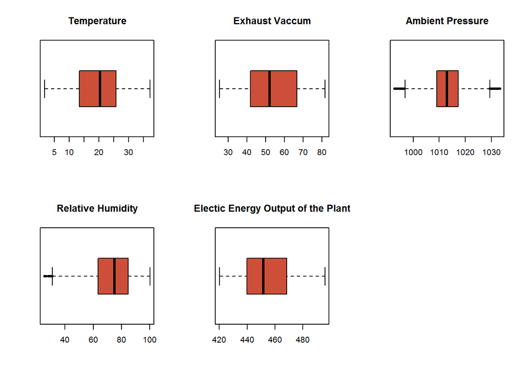

```r
attach(CCPP)
par(mfrow=c(2,3))
boxplot(AT, main="Temperature", horizontal = TRUE, col = "tomato3")
boxplot(V, main="Exhaust Vaccum", horizontal = TRUE, col = "tomato3")
boxplot(AP, main="Ambient Pressure", horizontal = TRUE, col ="tomato3" )
boxplot(RH, main="Relative Humidity", horizontal = TRUE, col = "tomato3")
boxplot(PE, main="Electic Energy Output of the Plant", horizontal = TRUE, col = "tomato3")
par(mfrow=c(2,3))
```

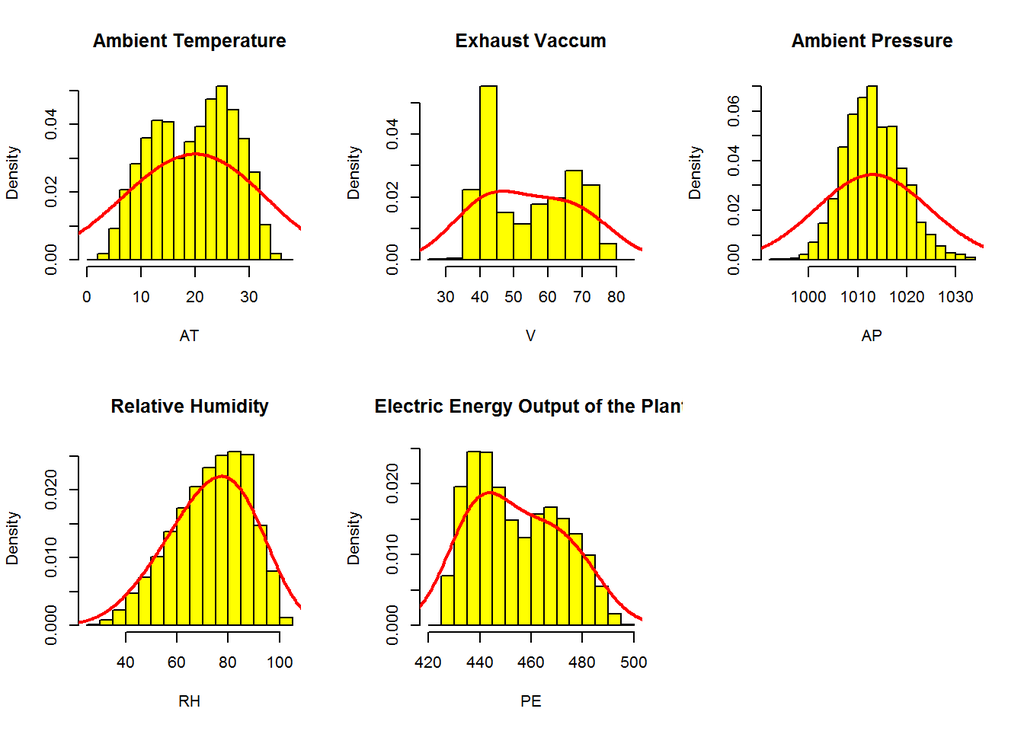

```r
hist(AT, main="Ambient Temperature", breaks=20, col="yellow", freq = FALSE)
lines(density(AT, bw=10), type = "l", col="red", lwd=2)
hist(V, main="Exhaust Vaccum", breaks=20, col="yellow", freq = FALSE)
lines(density(V, bw=10), type = "l", col="red", lwd=2)
hist(AP, main="Ambient Pressure", breaks=20, col="yellow", freq = FALSE)
lines(density(AP, bw=10), type = "l", col="red", lwd=2)
hist(RH, main="Relative Humidity", breaks=20, col="yellow", freq = FALSE)
lines(density(RH, bw=10), type = "l", col="red", lwd=2)
hist(PE, main="Electric Energy Output of the Plant", breaks=20, col="yellow", freq = FALSE)
lines(density(PE, bw=10), type = "l", col="red", lwd=2)
par(mfrow=c(2,2))
```

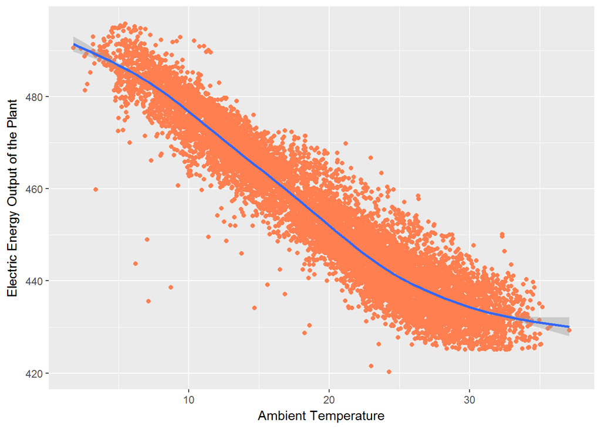

```r
ggplot(CCPP, aes(x=AT, y=PE))+
  geom_point(col="coral")+
   geom_smooth(model = lm)+
  labs(x="Ambient Temperature", y="Electric Energy Output of the Plant")
```

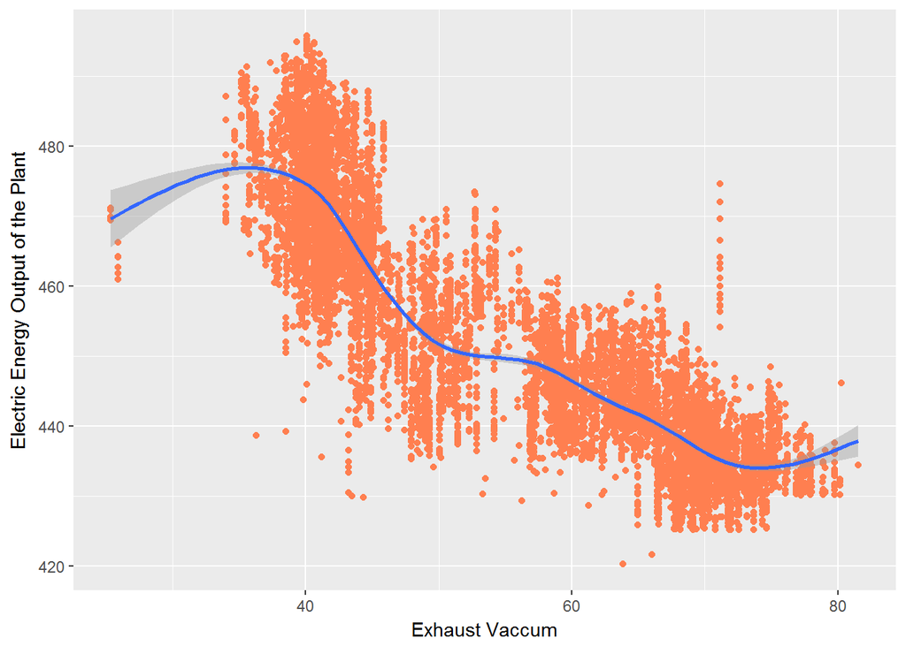

```r
ggplot(CCPP, aes(x=V, y=PE))+
  geom_point(col="coral")+
   geom_smooth(model = lm)+
    labs(x="Exhaust Vaccum", y="Electric Energy Output of the Plant")
```

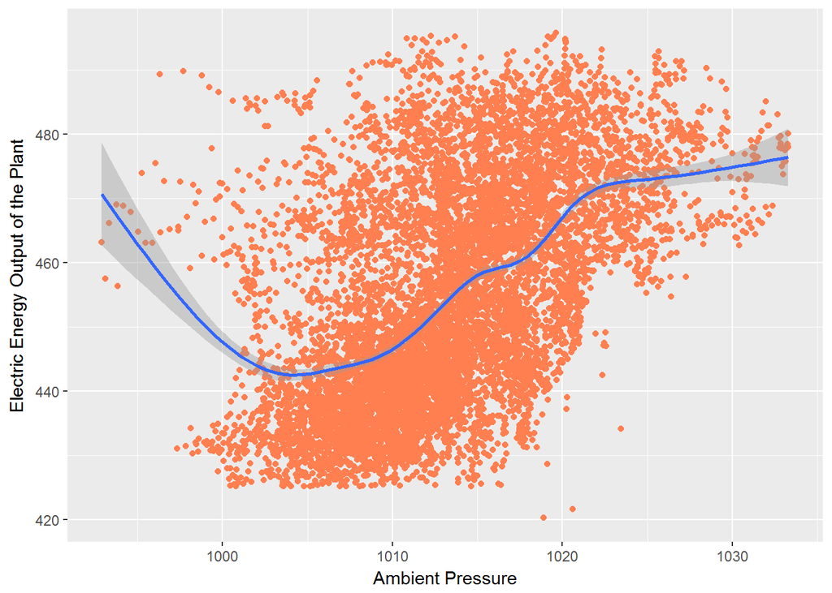

```r
ggplot(CCPP, aes(x=AP, y=PE))+
  geom_point(col="coral")+
   geom_smooth(model = lm)+
    labs(x="Ambient Pressure", y="Electric Energy Output of the Plant")
```

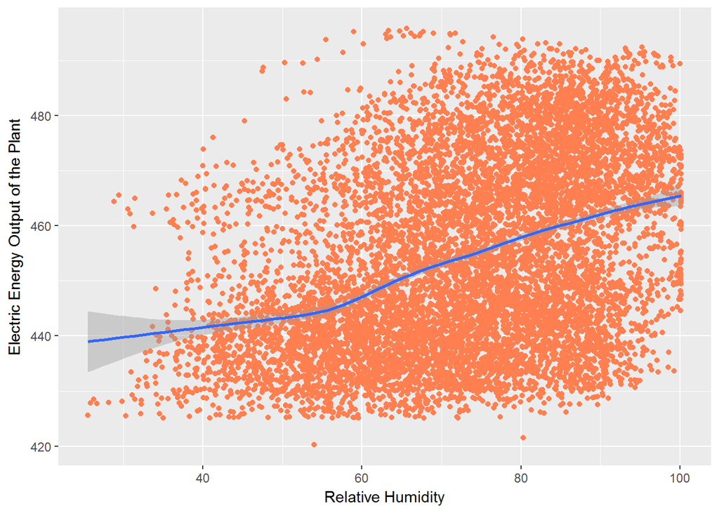

```r
ggplot(CCPP, aes(x=RH, y=PE))+
  geom_point(col="coral")+
   geom_smooth(model = lm)+
    labs(x="Relative Humidity", y="Electric Energy Output of the Plant")
```

# Creating a Correlation Matrix Heatmap

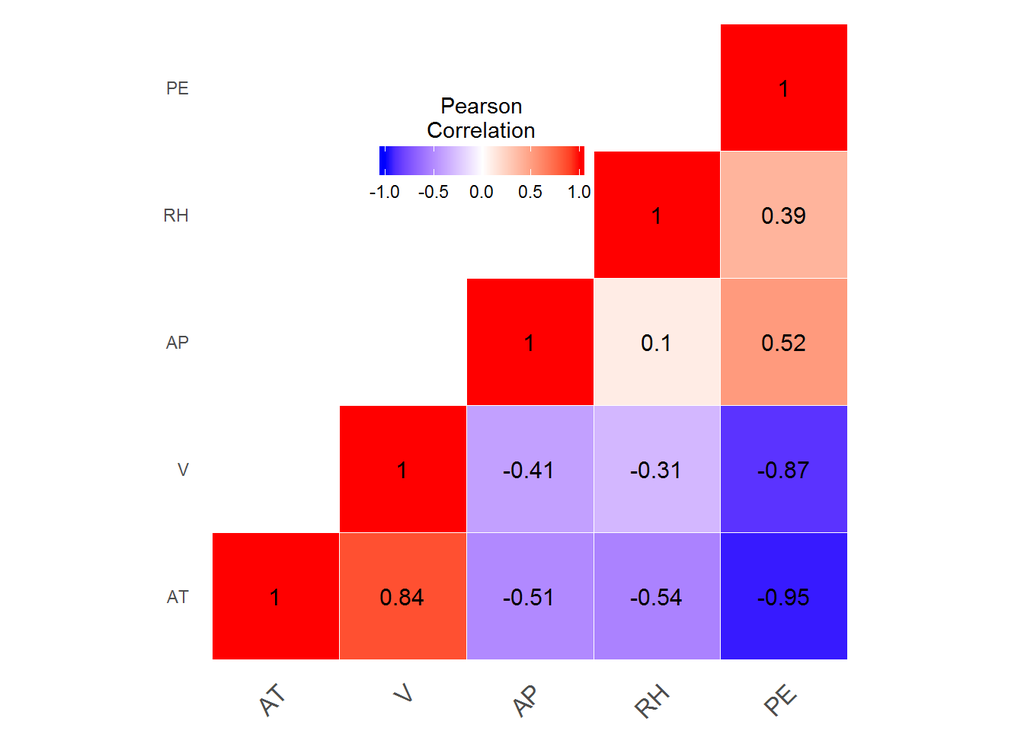

```r
matrix <- round(cor(CCPP),2)
# Getting lower triangle of the correlation matrix
  get_lower_tri<-function(matrix){
    matrix[upper.tri(matrix)] <- NA
    return(matrix)
  }
  # Getting upper triangle of the correlation matrix
  get_upper_tri <- function(matrix){
    matrix[lower.tri(matrix)]<- NA
    return(matrix)
  }
upper_tri <- get_upper_tri(matrix)
# Melt the correlation matrix
library(reshape2)
melted_cormat <- melt(upper_tri, na.rm = TRUE)
# Heatmap
library(ggplot2)
#reordering the correlation matrix according to the correlation coefficient is useful to identify the hidden pattern in the matrix. hclust for hierarchical clustering order is used below in the funtion defined.
reorder_cormat <- function(cormat){
# Use correlation between variables as distance
dd <- as.dist((1-cormat)/2)
hc <- hclust(dd)
cormat <-cormat[hc$order, hc$order]
}
# Reorder the correlation matrix
cormat <- reorder_cormat(matrix)
upper_tri <- get_upper_tri(matrix)
# Melt the correlation matrix
melted_cormat <- melt(upper_tri, na.rm = TRUE)
# Create a ggheatmap
ggheatmap <- ggplot(melted_cormat, aes(Var2, Var1, fill = value))+
 geom_tile(color = "white")+
 scale_fill_gradient2(low = "blue", high = "red", mid = "white",
   midpoint = 0, limit = c(-1,1), space = "Lab",
    name="Pearson\nCorrelation") +
  theme_minimal()+ # minimal theme
 theme(axis.text.x = element_text(angle = 45, vjust = 1,
    size = 12, hjust = 1))+
 coord_fixed()
#Adding correlation coefficients on the heatmap
#Using geom_text() to add the correlation coefficients on the graph
#Using a blank theme (remove axis labels, panel grids and background, and axis ticks)
#Using guides() to change the position of the legend title
ggheatmap +
geom_text(aes(Var2, Var1, label = value), color = "black", size = 4) +
theme(
  axis.title.x = element_blank(),
  axis.title.y = element_blank(),
  panel.grid.major = element_blank(),
  panel.border = element_blank(),
  panel.background = element_blank(),
  axis.ticks = element_blank(),
  legend.justification = c(1, 0),
  legend.position = c(0.6, 0.7),
  legend.direction = "horizontal")+
  guides(fill = guide_colorbar(barwidth = 7, barheight = 1,
                title.position = "top", title.hjust = 0.5))
```

# ScatterPlots of Electric Energy Output of the Plant vs. Other Variables in the Dataset.

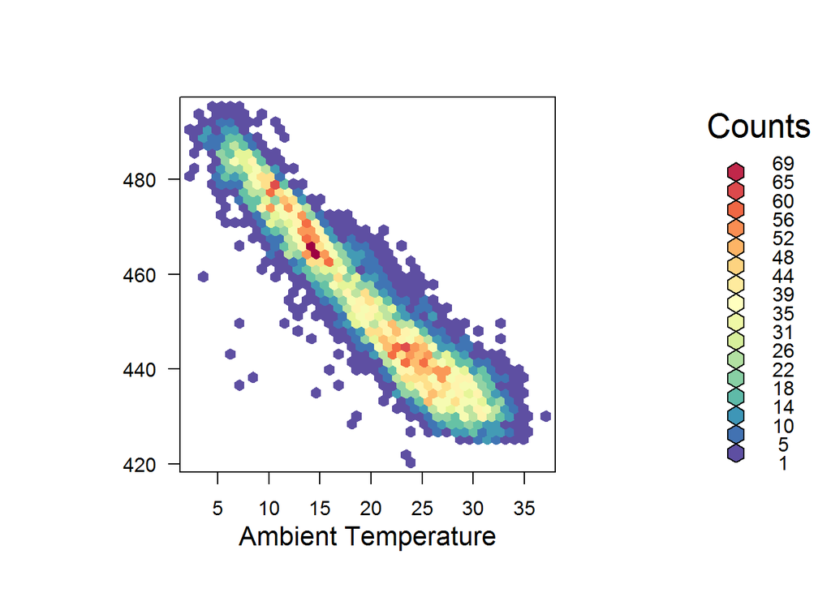

```r
library(hexbin)
library(RColorBrewer)
bin1 <- hexbin(AT, PE, xbins = 40)
bin2 <- hexbin(V, PE, xbins = 40)
bin3 <- hexbin(AP, PE, xbins = 40)
bin4 <- hexbin(RH, PE, xbins = 40)
my_colors=colorRampPalette(rev(brewer.pal(11,'Spectral')))
plot(bin1, main="", xlab= "Ambient Temperature", ylab="", colramp=my_colors)
```

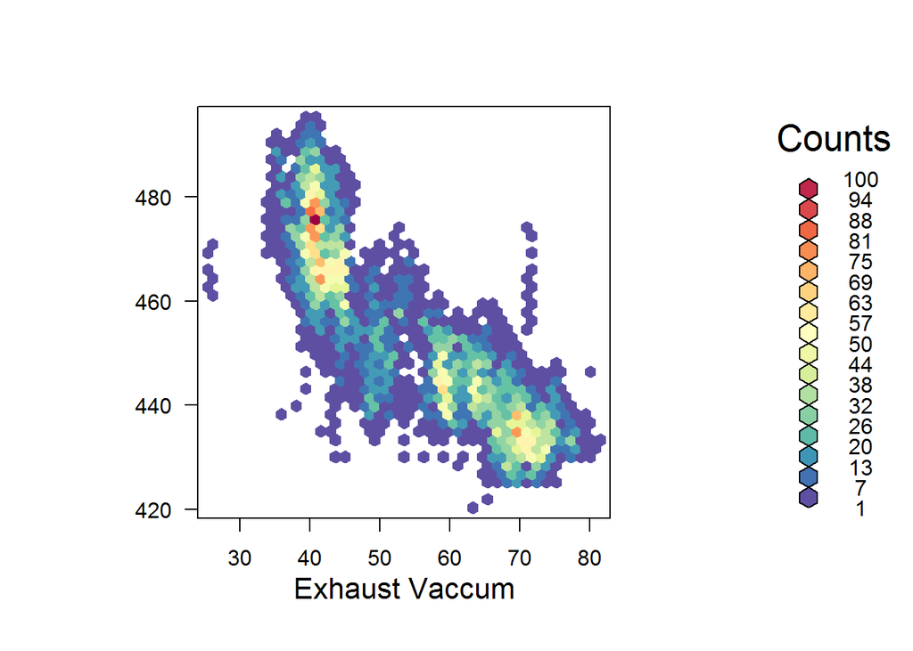

```r
plot(bin2, main="", xlab= "Exhaust Vaccum", ylab="", colramp=my_colors)
```

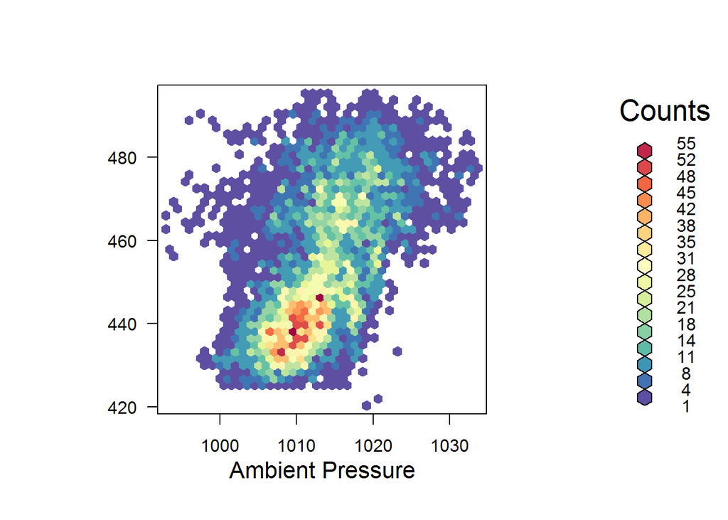

```r
plot(bin3, main="", xlab= "Ambient Pressure", ylab="", colramp=my_colors)
```

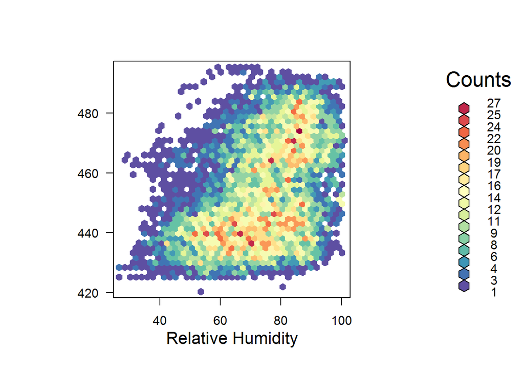

```r
plot(bin4, main="", xlab= "Relative Humidity", ylab="", colramp=my_colors)
```

# Null Hypothesis : **The net hourly electrical energy output of the plant is independent of the Ambient Temperature, Exhaust Vaccum, Ambient Pressure and Relative Humidity values detected by the sensors during that hour.**

## Chi-squared Tests of Independence

```r
tbl1 <- table(AT,PE)
tbl2 <- table(V,PE)
tbl3 <- table(AP,PE)
tbl4 <- table(RH,PE)
chisq.test(tbl1)
```

```
##
##  Pearson's Chi-squared test
##
## data:  tbl1
## X-squared = 14014000, df = 13403000, p-value < 2.2e-16
```

```r
chisq.test(tbl2)
```

```
##
##  Pearson's Chi-squared test
##
## data:  tbl2
## X-squared = 3056600, df = 3060600, p-value = 0.9431
```

```r
chisq.test(tbl3)
```

```
##
##  Pearson's Chi-squared test
##
## data:  tbl3
## X-squared = 12456000, df = 12165000, p-value < 2.2e-16
```

```r
chisq.test(tbl4)
```

```
##
##  Pearson's Chi-squared test
##
## data:  tbl4
## X-squared = 22004000, df = 21975000, p-value = 6.578e-06
```

### According to Chi-squared Tests of Independence, 3 out of 4 variables didn’t follow the null hypothesis as their p values are very less than 0.05. Hence for Ambient Temperature, Ambient Pressure and Relative humidity, the null hypothesis fails. Though according to this test, Exhaust vaccum follows the null hypothesis.

# Regression Analysis

```r
fit <- lm(PE~AT+V+AP+RH,CCPP)
library(sjPlot)
sjt.lm(fit, show.header = TRUE, emph.p = TRUE, string.dv = "The net hourly electrical energy output of the plant")
```

| *Predictors* | *The net hourly electrical energy output of the plant* |  |  |  |  |
| --- | --- | --- | --- | --- | --- |
|  |  |  | B | CI | p |
| (Intercept) |  | 454.61 | 435.50 – 473.72 | **<.001** |  |
| AT |  | -1.98 | -2.01 – -1.95 | **<.001** |  |
| V |  | -0.23 | -0.25 – -0.22 | **<.001** |  |
| AP |  | 0.06 | 0.04 – 0.08 | **<.001** |  |
| RH |  | -0.16 | -0.17 – -0.15 | **<.001** |  |
| Observations |  | 9568 |  |  |  |
| R<sup>2</sup> / adj. R<sup>2</sup> |  | .929 / .929 |  |  |  |

# Regression Diagnostics

## The assumptions for linear regression are:

### *Linearity: The relationship between X and the mean of Y is linear.*

### *Homoscedasticity: The variance of residual is the same for any value of X.*

### *Independence: Observations are independent of each other.*

### *Normality: For any fixed value of X, Y is normally distributed.*

## Component+Residual Plots

```r
library(car)
```

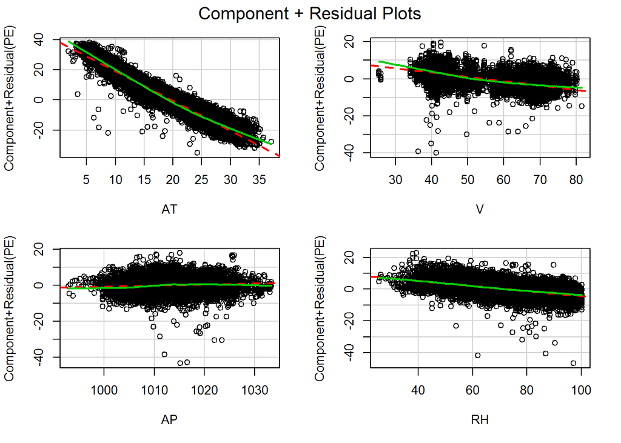

```r
library(broom)
crPlots(fit)
```

```r
aug.data = augment(fit) ###Store residuals into dataframe
```

## Residual Plots

```r
library(ggfortify)
```

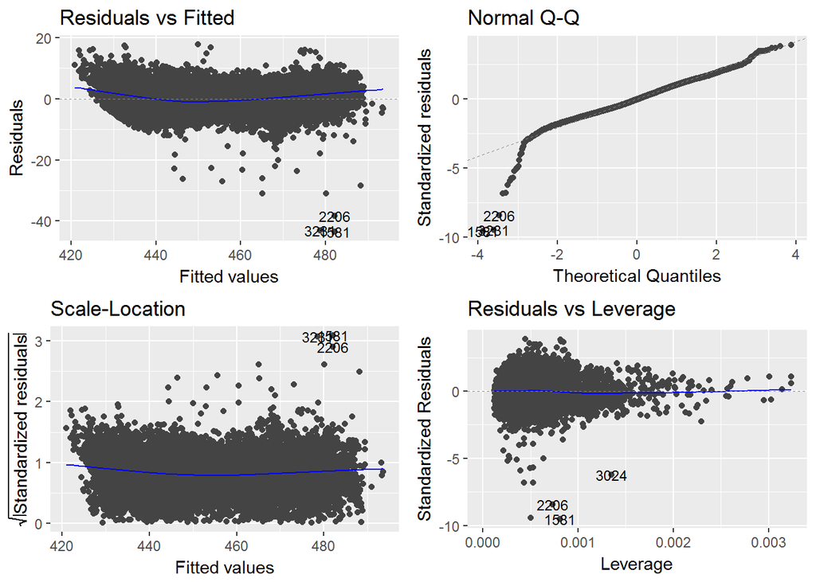

```r
autoplot(fit, label.size = 3)
```

## Testing Outliers

```r
outlierTest(fit)
```

```
##       rstudent unadjusted p-value Bonferonni p
## 1581 -9.577798         1.2395e-21   1.1859e-17
## 3231 -9.487390         2.9376e-21   2.8107e-17
## 2206 -8.448690         3.3759e-17   3.2301e-13
## 5949 -6.835304         8.6831e-12   8.3080e-08
## 3540 -6.820705         9.6082e-12   9.1931e-08
## 3024 -6.233478         4.7546e-10   4.5492e-06
## 9496 -5.924763         3.2355e-09   3.0957e-05
## 6561 -5.745868         9.4249e-09   9.0177e-05
## 8592 -5.702510         1.2156e-08   1.1631e-04
## 4798 -5.207803         1.9507e-07   1.8664e-03
```

### Though there are some outliers, but when the number is compared with total number of datapoints, it becomes insignificant.

## Checking Multicollinearity

**Theory**  
*Variance inflation factors measure the inflation in the variances of the parameter estimates due to collinearities that exist among the predictors. It is a measure of how much the variance of the estimated regression coefficient is “inflated” by the existence of correlation among the predictor variables in the model. A VIF of 1 means that there is no correlation among the kth predictor and the remaining predictor variables, and hence the variance of the estimated regression coefficient is not inflated at all. The general rule of thumb is that VIFs exceeding 4 warrant further investigation, while VIFs exceeding 10 are signs of serious multicollinearity requiring correction.*

```r
vif(fit)
```

```
##       AT        V       AP       RH
## 5.977602 3.943003 1.452639 1.705290
```

```r
sqrt(vif(fit)) > 2
```

```
##    AT     V    AP    RH
##  TRUE FALSE FALSE FALSE
```

### This model has collinearity issue. Hence, it is ideal to select a model with uncorrelated predictors.

# Testing Heteroscadasticity

**Theory**  
Heteroscadasticity *refers to the circumstance in which the variability of a variable is unequal across the range of values of a second variable that predicts it.*  
Non-constant Variance Score Test : *This test is more prominently know as Breusch-Pagan test. It is a test for heteroscedasticity. In a standard linear model, the variance of the residuals are assumed to be constant (i.e. independent) over the values of the response (fitted values).*

```r
ncvTest(fit)
```

```
## Non-constant Variance Score Test
## Variance formula: ~ fitted.values
## Chisquare = 7.513071    Df = 1     p = 0.006125284
```

### The p value is <0.05. Therefore we can reject the null hypothesis that the variance of the residuals is constant. Hence, there is a heteroscadasticity issue associated with the model.

# Choosing the Best Model

```r
mod1 = lm(PE ~ AT + RH + AP, data=CCPP)
mod2 = lm(PE ~ AT + RH + V, data=CCPP)
mod3 = lm(PE ~ AT + V + AP, data=CCPP)
mod4 = lm(PE ~ V + RH + AP, data=CCPP)
mod5 = lm(PE ~ V + RH, data=CCPP)
mod6 = lm(PE ~ RH + AP, data=CCPP)
mod7 = lm(PE ~ AT + RH, data=CCPP)
mod8 = lm(PE ~ AT + AP, data=CCPP)
mod9 = lm(PE ~ V+ AP, data=CCPP)
mod10 = lm(PE ~ AT + V, data=CCPP)
par(mfrow=c(2,5))
sjt.lm(mod1, show.header = TRUE, emph.p = TRUE, string.dv = "The net hourly electrical energy output of the plant")
```

| *Predictors* | *The net hourly electrical energy output of the plant* |  |  |  |  |
| --- | --- | --- | --- | --- | --- |
|  |  |  | B | CI | p |
| (Intercept) |  | 490.32 | 470.34 – 510.31 | **<.001** |  |
| AT |  | -2.38 | -2.40 – -2.36 | **<.001** |  |
| RH |  | -0.20 | -0.21 – -0.20 | **<.001** |  |
| AP |  | 0.03 | 0.01 – 0.04 | **.010** |  |
| Observations |  | 9568 |  |  |  |
| R<sup>2</sup> / adj. R<sup>2</sup> |  | .921 / .921 |  |  |  |

```r
sjt.lm(mod2, show.header = TRUE, emph.p = TRUE, string.dv = "The net hourly electrical energy output of the plant")
```

| *Predictors* | *The net hourly electrical energy output of the plant* |  |  |  |  |
| --- | --- | --- | --- | --- | --- |
|  |  |  | B | CI | p |
| (Intercept) |  | 518.55 | 517.79 – 519.31 | **<.001** |  |
| AT |  | -2.02 | -2.05 – -1.99 | **<.001** |  |
| RH |  | -0.17 | -0.17 – -0.16 | **<.001** |  |
| V |  | -0.23 | -0.24 – -0.21 | **<.001** |  |
| Observations |  | 9568 |  |  |  |
| R<sup>2</sup> / adj. R<sup>2</sup> |  | .928 / .928 |  |  |  |

```r
sjt.lm(mod3, show.header = TRUE, emph.p = TRUE, string.dv = "The net hourly electrical energy output of the plant")
```

| *Predictors* | *The net hourly electrical energy output of the plant* |  |  |  |  |
| --- | --- | --- | --- | --- | --- |
|  |  |  | B | CI | p |
| (Intercept) |  | 344.07 | 324.51 – 363.63 | **<.001** |  |
| AT |  | -1.63 | -1.66 – -1.61 | **<.001** |  |
| V |  | -0.33 | -0.34 – -0.31 | **<.001** |  |
| AP |  | 0.16 | 0.14 – 0.18 | **<.001** |  |
| Observations |  | 9568 |  |  |  |
| R<sup>2</sup> / adj. R<sup>2</sup> |  | .918 / .918 |  |  |  |

```r
sjt.lm(mod4, show.header = TRUE, emph.p = TRUE, string.dv = "The net hourly electrical energy output of the plant")
```

| *Predictors* | *The net hourly electrical energy output of the plant* |  |  |  |  |
| --- | --- | --- | --- | --- | --- |
|  |  |  | B | CI | p |
| (Intercept) |  | -74.97 | -103.73 – -46.22 | **<.001** |  |
| V |  | -1.00 | -1.02 – -0.99 | **<.001** |  |
| RH |  | 0.16 | 0.15 – 0.17 | **<.001** |  |
| AP |  | 0.56 | 0.54 – 0.59 | **<.001** |  |
| Observations |  | 9568 |  |  |  |
| R<sup>2</sup> / adj. R<sup>2</sup> |  | .804 / .804 |  |  |  |

```r
sjt.lm(mod5, show.header = TRUE, emph.p = TRUE, string.dv = "The net hourly electrical energy output of the plant")
```

| *Predictors* | *The net hourly electrical energy output of the plant* |  |  |  |  |
| --- | --- | --- | --- | --- | --- |
|  |  |  | B | CI | p |
| (Intercept) |  | 503.59 | 502.28 – 504.90 | **<.001** |  |
| V |  | -1.11 | -1.13 – -1.10 | **<.001** |  |
| RH |  | 0.15 | 0.14 – 0.16 | **<.001** |  |
| Observations |  | 9568 |  |  |  |
| R<sup>2</sup> / adj. R<sup>2</sup> |  | .772 / .772 |  |  |  |

```r
sjt.lm(mod6, show.header = TRUE, emph.p = TRUE, string.dv = "The net hourly electrical energy output of the plant")
```

| *Predictors* | *The net hourly electrical energy output of the plant* |  |  |  |  |
| --- | --- | --- | --- | --- | --- |
|  |  |  | B | CI | p |
| (Intercept) |  | -985.49 | -1031.41 – -939.58 | **<.001** |  |
| RH |  | 0.40 | 0.38 – 0.42 | **<.001** |  |
| AP |  | 1.39 | 1.35 – 1.44 | **<.001** |  |
| Observations |  | 9568 |  |  |  |
| R<sup>2</sup> / adj. R<sup>2</sup> |  | .384 / .384 |  |  |  |

```r
sjt.lm(mod7, show.header = TRUE, emph.p = TRUE, string.dv = "The net hourly electrical energy output of the plant")
```

| *Predictors* | *The net hourly electrical energy output of the plant* |  |  |  |  |
| --- | --- | --- | --- | --- | --- |
|  |  |  | B | CI | p |
| (Intercept) |  | 516.48 | 515.69 – 517.26 | **<.001** |  |
| AT |  | -2.39 | -2.41 – -2.38 | **<.001** |  |
| RH |  | -0.21 | -0.21 – -0.20 | **<.001** |  |
| Observations |  | 9568 |  |  |  |
| R<sup>2</sup> / adj. R<sup>2</sup> |  | .921 / .921 |  |  |  |

```r
sjt.lm(mod8, show.header = TRUE, emph.p = TRUE, string.dv = "The net hourly electrical energy output of the plant")
```

| *Predictors* | *The net hourly electrical energy output of the plant* |  |  |  |  |
| --- | --- | --- | --- | --- | --- |
|  |  |  | B | CI | p |
| (Intercept) |  | 349.95 | 328.45 – 371.45 | **<.001** |  |
| AT |  | -2.11 | -2.13 – -2.10 | **<.001** |  |
| AP |  | 0.14 | 0.12 – 0.17 | **<.001** |  |
| Observations |  | 9568 |  |  |  |
| R<sup>2</sup> / adj. R<sup>2</sup> |  | .901 / .901 |  |  |  |

```r
sjt.lm(mod9, show.header = TRUE, emph.p = TRUE, string.dv = "The net hourly electrical energy output of the plant")
```

| *Predictors* | *The net hourly electrical energy output of the plant* |  |  |  |  |
| --- | --- | --- | --- | --- | --- |
|  |  |  | B | CI | p |
| (Intercept) |  | -45.67 | -75.57 – -15.76 | **.003** |  |
| V |  | -1.06 | -1.08 – -1.05 | **<.001** |  |
| AP |  | 0.55 | 0.52 – 0.58 | **<.001** |  |
| Observations |  | 9568 |  |  |  |
| R<sup>2</sup> / adj. R<sup>2</sup> |  | .787 / .787 |  |  |  |

```r
sjt.lm(mod10, show.header = TRUE, emph.p = TRUE, string.dv = "The net hourly electrical energy output of the plant")
```

| *Predictors* | *The net hourly electrical energy output of the plant* |  |  |  |  |
| --- | --- | --- | --- | --- | --- |
|  |  |  | B | CI | p |
| (Intercept) |  | 505.48 | 505.01 – 505.95 | **<.001** |  |
| AT |  | -1.70 | -1.73 – -1.68 | **<.001** |  |
| V |  | -0.32 | -0.34 – -0.31 | **<.001** |  |
| Observations |  | 9568 |  |  |  |
| R<sup>2</sup> / adj. R<sup>2</sup> |  | .916 / .916 |  |  |  |

**Now, we refine our selection to mod1 and mod2.**

## Checking Multicollinearity

```r
sqrt(vif(mod1)) > 2
```

```
##    AT    RH    AP
## FALSE FALSE FALSE
```

```r
sqrt(vif(mod2)) > 2
```

```
##    AT    RH     V
##  TRUE FALSE FALSE
```

## Testing Heteroscadasticity

```r
ncvTest(mod1)
```

```
## Non-constant Variance Score Test
## Variance formula: ~ fitted.values
## Chisquare = 0.6041578    Df = 1     p = 0.436996
```

```r
ncvTest(mod2)
```

```
## Non-constant Variance Score Test
## Variance formula: ~ fitted.values
## Chisquare = 3.169887    Df = 1     p = 0.07500765
```

**Hence we select mod1.**

## Coefficients of the Model

```r
coef(mod1)
```

```
##  (Intercept)           AT           RH           AP
## 490.32374639  -2.37770850  -0.20383189   0.02537245
```

**So, the model with predictor variables AT, RH & AP produces the better energy output.**

# Final Model : **Energy Output** (PE) = 490.323746 -2.377708**Temperature**(AT) - 0.203832**Humidity**(RH) + 0.025372 **Pressure**(AP)

# Summarizing

## *Because air density varies inversely with ambient temperature, the air mass flow rate entering in a typical machine of specific size and rotational speed is reduced on a hot day. The air temperature has a large influence on the power output and efficiency of a gas turbine.Power output is reduced when the temperature is above the standard ambient temperature*

## *Similarly as the relative Humidity increases, it inversely affects the air flow mass rate hence decreasing the net energy output.*

## *As for the ambient pressure, more the ambient pressure, more the air flow rate. Hence affecting the effciency positively.*

## But overall, Ambient Temperature is relatively the most important variable for this linear model.